# Transducer and Ground Water Data Visualization / Working Doc

Inigo Peng, Cameron Tenner, Maddee Wiggins

2024-10-29

# 1 Surface Water Data

## 1.1 BVR EPA Data

### 1.1.1 Description of Data

The surface water data is periodically collected by Big Valley Rancheria using Rugged Troll 200. The data have been corrected using barometric pressure measurements.

**Timeframe:**

Surface Water Data: 2018-12-13 09:00:00 - 2024-09-06 11:45:00

**Completeness of record throughout timeframe:** Complete

**Sampling Location**:

Surface Water Data: Pressure transducers are located in the creek bed at Bell Hill Rd, Argonaut Rd, and Soda Bay Rd. #TODO: add other sites

**Data Contact:**

### 1.1.2 Access BVR EPA Data:

## 1.2 3rd-Party Data

### 1.2.1 Description of Data

- USGS data on clearlake level and kelsey creek at kelseyville
- Waterboard surface water data collected at Bell Hill Rd
- County groundwater wells A1, J1, and G2

### 1.2.2 Access 3rd-Party Data

```r
clearlake_level <- readNWISdv("11450000", "00065","2007-10-01", Sys.Date()) |>
  mutate(WSE = X_00065_00003 + 1318.26,
         Date = as.POSIXct(Date, tz = "America/Los_Angeles"))

SW_bellhill_WB <- readxl::read_xlsx(here::here('data-raw', 'surface_water', 'water_board', 'PressureTransducer_and_Flow_Data_20230728.xlsx'),
                                    sheet = "AC4-2023 Data", skip=8)  |>
  mutate(Date = as.POSIXct(`Date Time (UTC)`),
         Date = with_tz(Date, "America/Los_Angeles"))

SW_kelsey_kelseyville_USGS <- read_csv(here::here('data-raw', 'surface_water', 'kelsey_kelseyville_usgs_stage_20240201.csv'))  |>
  mutate(Datetime = as.POSIXct(Datetime, format = "%m/%d/%Y %H:%M", tz = "America/Los_Angeles"),
         WSE = Stage + 1475.44)
```

# 2 Data Processing and Visualization:

## 2.1 Surface Water Data:

### 2.1.1 Raw Data

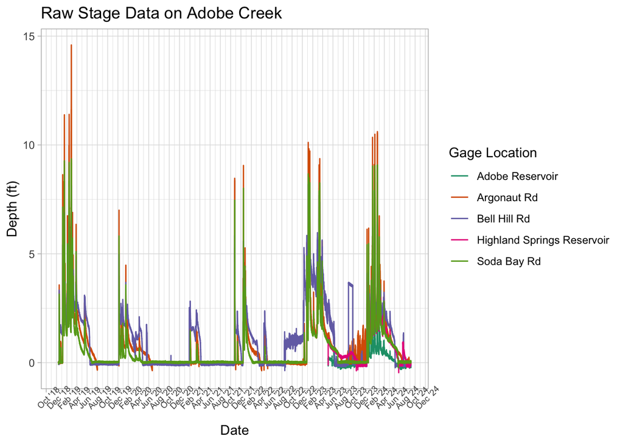

Between 08/15/2022 and 12/07/2022 going to assign NA values to Bell Hill Rd. After 12/07/2022 and until depths drop to ~0 on 06/10/23, going to correct depths -1.9 ft. This depth is derived from transect taken on 1/24/2023.

Also the issue of the removal of the transducer…addressed by steps below that cut off Bell Hill record in April 2023

### 2.1.2 Datum Change Adjustment

```r
surface_water <- surface_water  |>
  mutate(depth_adjust =
           case_when(
             name == "Bell Hill Rd" &
               datetime > as.POSIXct("2022-08-15 07:30:00", tz="America/Los_Angeles") &
               datetime < as.POSIXct("2022-12-07 15:30:00", tz="America/Los_Angeles") ~
               0, #only way casewhen() will take NA value???
             name == "Bell Hill Rd" &
               datetime > as.POSIXct("2022-12-07 7:45:00", tz="America/Los_Angeles") &
               datetime < as.POSIXct("2023-06-10 15:00:00", tz="America/Los_Angeles") ~
               depth_ft - 1.9,
             T ~ depth_ft
  ))
```

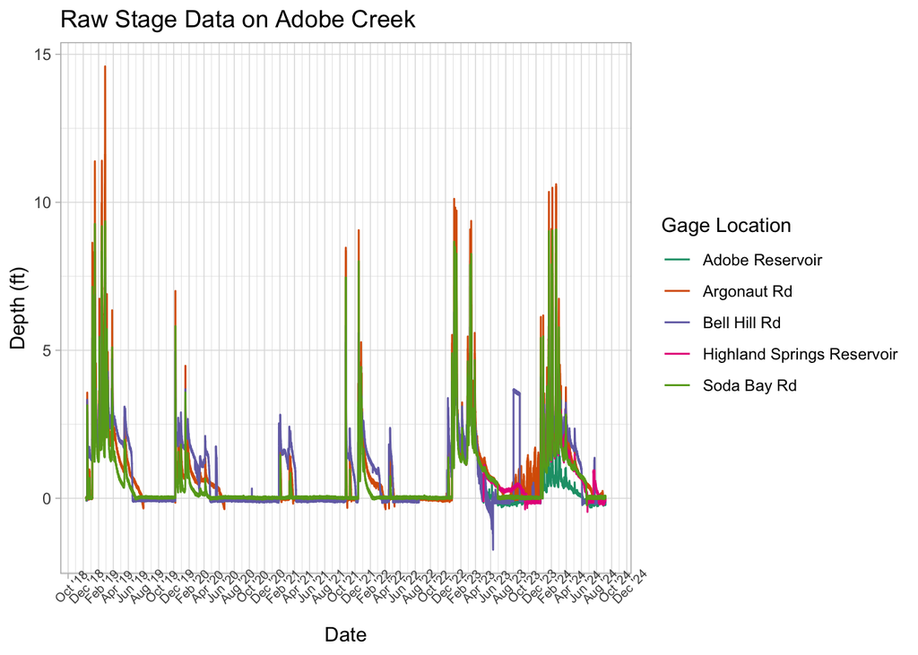

Bell Hill starts to look funky again later in the 2022/2023 winter, falling below 0 ft of depth.

Let’s compare this to the water board data to figure out how to proceed with this data.

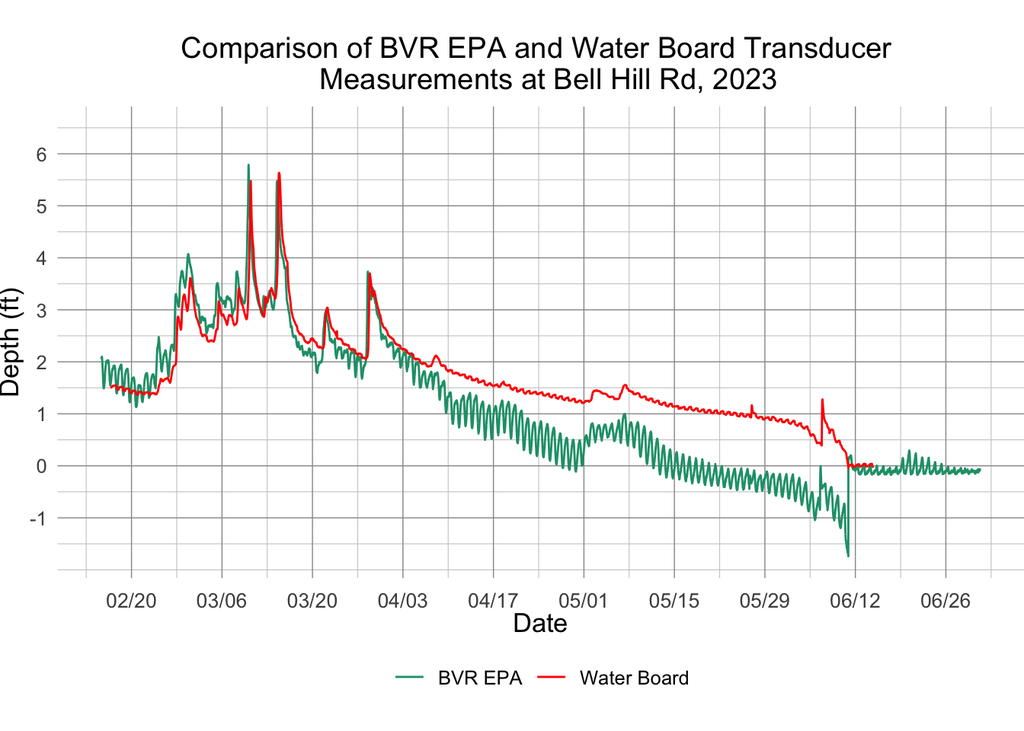

```r
plot_sw_bellhill <- ggplot(data = surface_water  |>filter(name == "Bell Hill Rd"), aes(x=datetime, y=depth_adjust, color = "BVR EPA")) +
  geom_line() +
  geom_line(data = SW_bellhill_WB, aes(x=Date, y = `Depth (ft)`, color = "Water Board")) +
  scale_color_manual(name = "", values = c("BVR EPA" = "#1B9E77", "Water Board" = "red")) +
  scale_y_continuous(limits = c(-1.75, 6.5), breaks = c(-1, 0, 1, 2, 3, 4, 5, 6)) +
  scale_x_datetime(date_labels = "%m/%d",
                   date_breaks = "2 weeks",
                   minor_breaks = "1 week",
                   limits = c(as.POSIXct("2023-02-15 00:00:00", tz="America/Los_Angeles"), as.POSIXct("2023-07-01 00:00:00", tz="America/Los_Angeles"))
  ) +
  labs(x = "Date", y = "Depth (ft)", title = "Comparison of BVR EPA and Water Board Transducer \n  Measurements at Bell Hill Rd, 2023") +
  theme_minimal() +
  theme(axis.text.x = element_text(size = 10, angle = 0, vjust = 0),
        panel.grid.major = element_line(colour = "grey60", size = 0.25),
        panel.grid.minor = element_line(colour = "grey80", size = 0.2),
        text = element_text(size = 12),
        plot.title = element_text(hjust=0.5),
        axis.title = element_text(size = 13),
        legend.position = "bottom",
        legend.direction = "horizontal",
        legend.margin = margin(t = 0, r = 0, b = 0, l = 0, unit = "in"),
        legend.title = element_blank(),
        plot.margin = margin(t = 0.25, r = 0, b = 0.25, l = 0, unit = "in"))

plot_sw_bellhill
```

```r
# ggsave(
#   "Figs/report/data_quality/BVR_WB_Comparison_BellHill.png",
#   plot_sw_bellhill,
#   device = "png",
#   width = 6,
#   height = 4,
#   units = "in"
# )
```

From this we see that the datum shift makes our data match with Water Board’s data at the same location for most of the winter.

However, they begin to diverge in early April of 2023.

To account for this, going to remove data between 04/05/2023 and 06/10/2023 for Bell Hill Gage.

```r
surface_water <- surface_water  |>
  mutate(depth_adjust02 =
           case_when(
             name == "Bell Hill Rd" &
               datetime > as.POSIXct("2023-04-05 08:00:00", tz="America/Los_Angeles") &
               datetime < as.POSIXct("2023-06-10 15:00:00", tz="America/Los_Angeles") ~
               NA_real_,
             name == "Bell Hill Rd" &
               datetime >= as.POSIXct("2023-09-01 08:00:00", tz="America/Los_Angeles") &
               datetime < as.POSIXct("2023-09-27 09:00:00", tz="America/Los_Angeles") ~
               0,
    T ~ depth_adjust
  ))
```

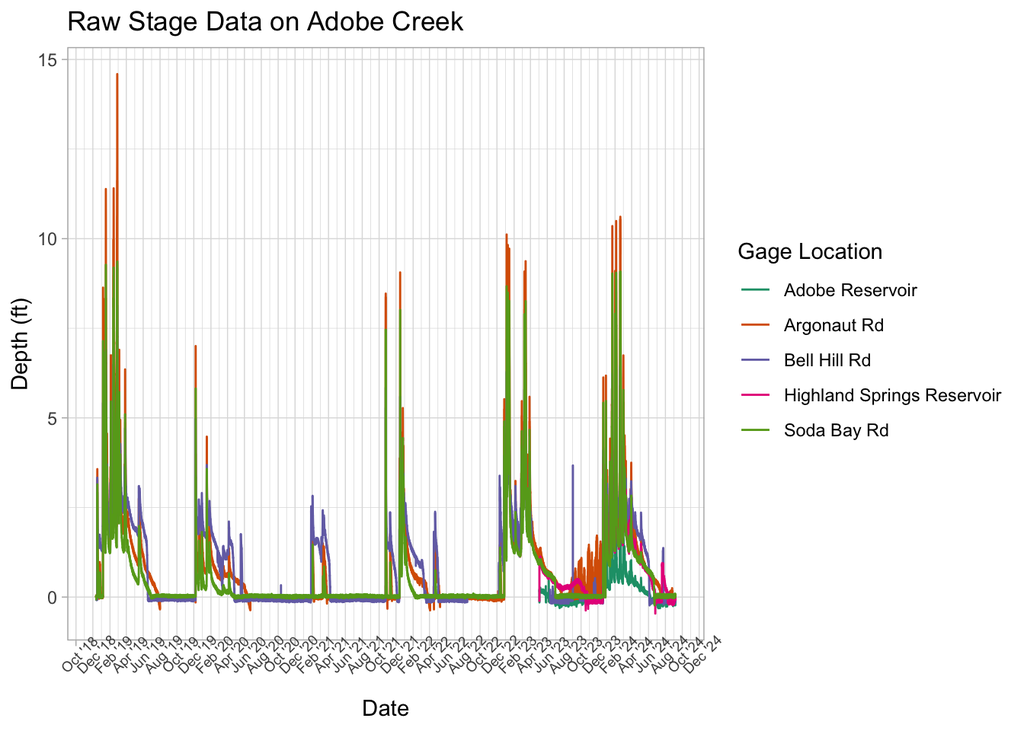

Issues with oscillations when creek is dry.

Lets vertically transform each dataset to get the zero flow values to roughly evenly distribute around 0 ft of depth. Then assign every value below the maximum of the oscillation to zero.

This code finds the average value of oscillating observations under dry conditions for each transducer

```r
bellhill_offset <- mean((surface_water|> filter(name == "Bell Hill Rd"))$depth_adjust02[(surface_water  |>filter(name == "Bell Hill Rd"))$depth_adjust02 <= 0.01], na.rm = T)

argonaut_offset <- mean((surface_water|> filter(name == "Argonaut Rd"))$depth_adjust02[(surface_water  |>filter(name == "Argonaut Rd"))$depth_adjust02 <= 0.062], na.rm = T)

sodabay_offset <- mean((surface_water |> filter(name == "Soda Bay Rd"))$depth_adjust02[(surface_water  |>filter(name == "Soda Bay Rd"))$depth_adjust02 <= 0.087], na.rm = T)

adoberes_offset <- mean((surface_water |> filter(name == "Adobe Reservoir"))$depth_adjust02[(surface_water  |>filter(name == "Adobe Reservoir"))$depth_adjust02 <= 0.059], na.rm = T)

highlandspringsres_offset <- mean((surface_water  |>filter(name == "Highland Springs Reservoir"))$depth_adjust02[(surface_water  |>filter(name == "Highland Springs Reservoir"))$depth_adjust02 <= -0.086], na.rm = T)
```

Then we perform a vertical transformation with this value

```r
surface_water <- surface_water  |>
  mutate(depth_adjust03 = case_when(
    # The following numbers are derived from the maximum "zero flow" values across whole record for each transducer
    name == "Bell Hill Rd" ~ depth_adjust02 - bellhill_offset,
    name == "Argonaut Rd" ~ depth_adjust02 - argonaut_offset,
    name == "Soda Bay Rd" ~ depth_adjust02 - sodabay_offset,
    # Following values are based on an offset that will make the lowest oscillations oscillate around zero.
    name == "Adobe Reservoir" ~ depth_adjust02 - adoberes_offset,
    name == "Highland Springs Reservoir" ~ depth_adjust02 - highlandspringsres_offset,
    T ~ depth_adjust02
  ))
```

Dry values should now oscillate around 0 ft of depth

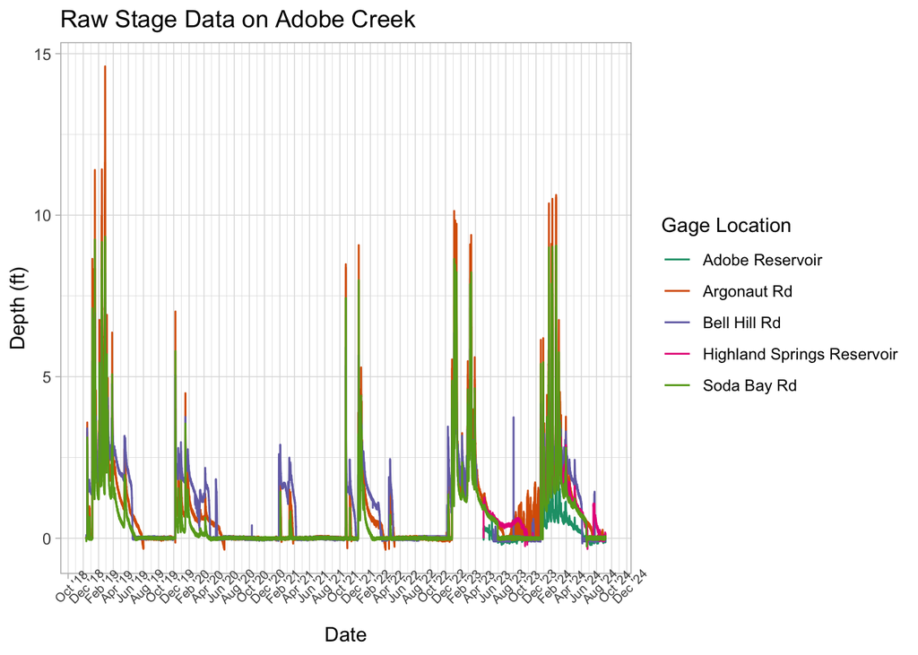

Looks great.

Now we assign all values less than or equal to the maximum observed depth among these dry conditions oscillations for each transducer to zero.

```r
surface_water <- surface_water|>
  mutate(
  depth_adjust03 = case_when(
    name == "Bell Hill Rd" & depth_adjust03 <= 0.0759 ~ 0,
    name == "Argonaut Rd" & depth_adjust03 < 0.0768 ~ 0,
    name == "Soda Bay Rd" & depth_adjust03 <= 0.0753 ~ 0,
    name == "Adobe Reservoir" & depth_adjust03 <= 0.063 ~ 0,
    name == "Highland Springs Reservoir" & depth_adjust03 <= 0.048 ~0,
    T ~ depth_adjust03
  ))
```

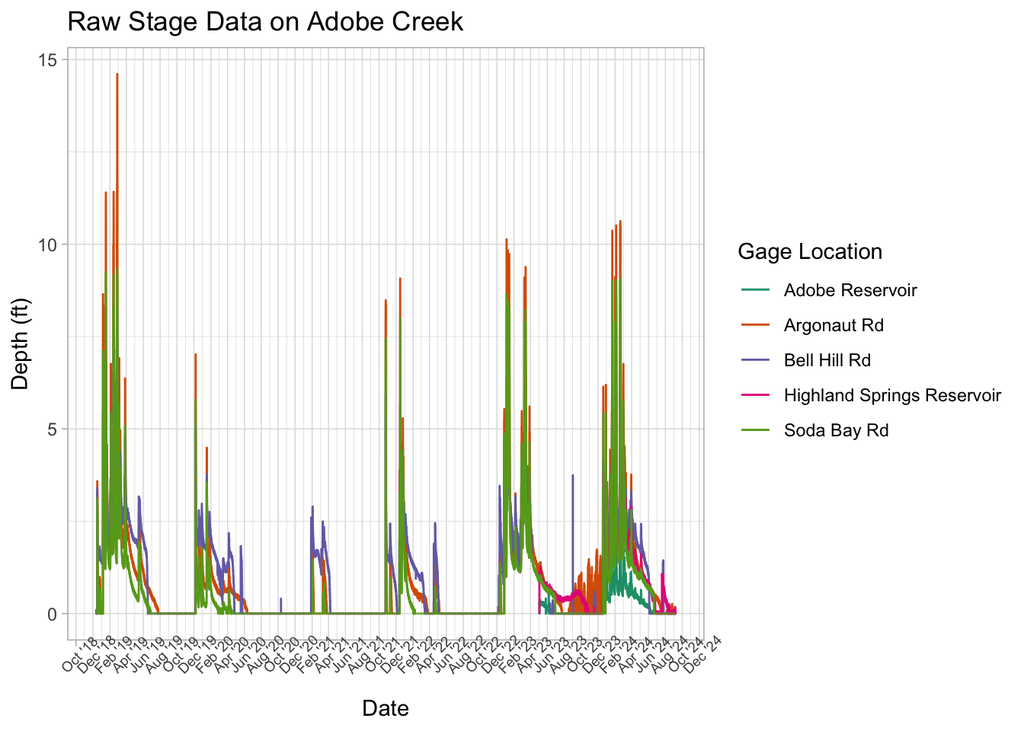

```r
transducer_all <- ggplot(data = surface_water, aes(x=datetime, y=depth_adjust03, color=name)) +
  geom_line() +
  theme_light() +
  scale_color_brewer(type = 'qual', palette = 'Dark2') +
  scale_x_datetime(date_labels = "%b '%y",
                   date_breaks = "2 months") +
  theme(axis.text.x = element_text(size = 7, angle = 45)) +
  labs(
    title = "Raw Stage Data on Adobe Creek",
    y = "Depth (ft)",
    color = "Gage Location",
    x = "Date"
  )

transducer_all
```

```r
# ggplotly(transducer_all)
```

Looks good!

Something odd is happening at Argonaut starting in August of 2023, lasting until the first rains of WY 2024 in December 2023. Sudden, high oscillation recordings while other gages show 0 flow, and precipitation record shows no precipitation. Let’s replace values between the pattern starting (08/15/2023) and first real flows of WY 2024 (12/19/2023).

```r
surface_water <- surface_water  |>
  mutate(depth_adjust04 =
           case_when(
             name == "Argonaut Rd" &
               datetime > as.POSIXct("2023-08-16 00:00:00", tz="America/Los_Angeles") &
               datetime < as.POSIXct("2023-12-19 09:15:00", tz="America/Los_Angeles") ~
               0,
    T ~ depth_adjust03
  ))
```

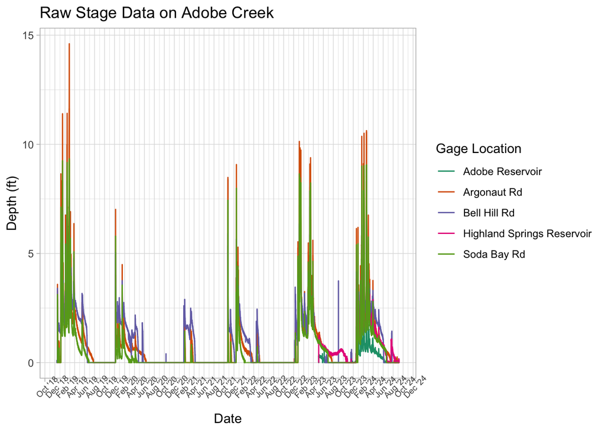

The data looks clean, but the sharp peaks make it more difficult to ascertain trends on a longer time interval. To remedy this, we will apply a 7 day moving average to the data.

### 2.1.3 Smoothed Data (Moving Average)

```r
surface_water <- surface_water  |>
  group_by(name)  |>
  mutate(
    depth_07dMA = rollmean(depth_adjust04, 672, fill=NA),
    depth_01dMA = rollmean(depth_adjust04, 96, fill=NA)
  )
```

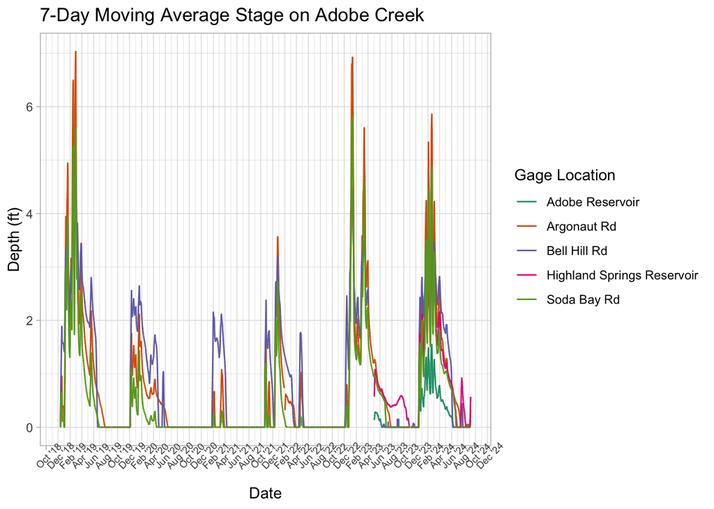

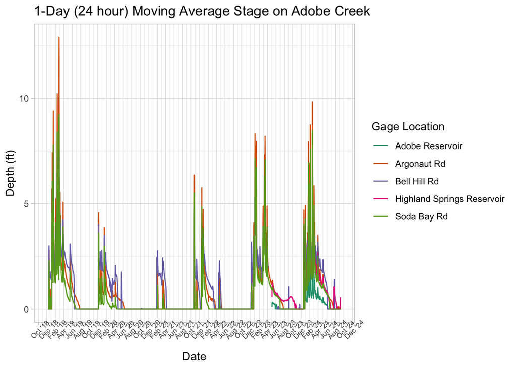

This 7-day moving average makes trends on a week time interval clearer and also better illustrates trends between the monitoring locations. To further interrogate relationships between monitoring locations, we take a look at mean monthly stages across the sites.

7 day moving avg figure for report

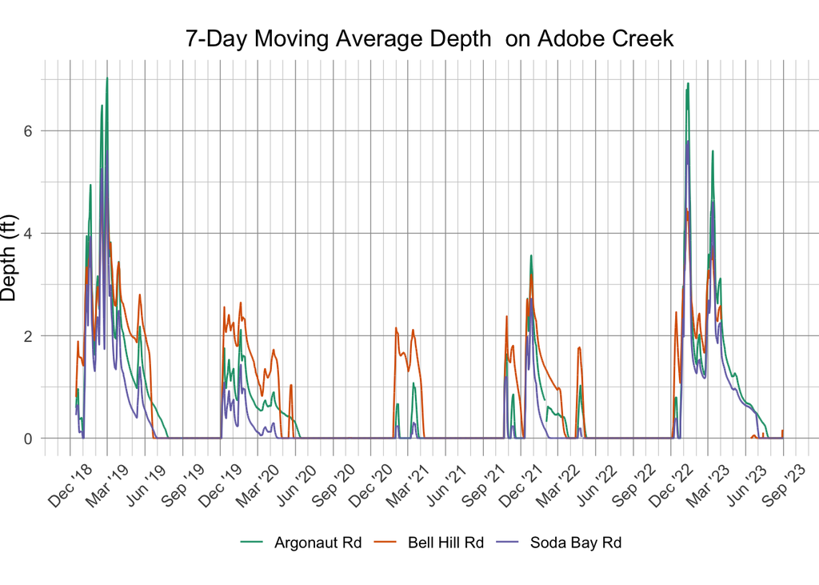

```r
tranducer_7dMA <- ggplot(data = surface_water  |>filter(name %in% c("Bell Hill Rd", "Argonaut Rd", "Soda Bay Rd")), aes(x=datetime, y=depth_07dMA, color=name)) +
  geom_line() +
  scale_color_brewer(type = 'qual', palette = 'Dark2') +
  scale_x_datetime(date_labels = "%b '%y",
                   date_breaks = "3 months",
                   date_minor_breaks = "1 month",
                   limits = c(as.POSIXct("2018-12-15 0:00:00", tz="America/Los_Angeles"), as.POSIXct("2023-09-01 0:00:00", tz="America/Los_Angeles"))) +
  labs(
    title = "7-Day Moving Average Depth  on Adobe Creek",
    y = "Depth (ft)",
    color = "Gage Location",
    x = "Date"
  ) +
  theme_minimal() +
  theme(axis.text.x = element_text(size = 10, angle = 45, vjust = 0.5, margin = margin(t = 0, r = 0, b = 0, l = 0, unit = "in")),
        axis.title.x = element_blank(),
        panel.grid.major = element_line(colour = "grey60", size = 0.25),
        panel.grid.minor = element_line(colour = "grey80", size = 0.2),
        text = element_text(size = 12),
        plot.title = element_text(hjust=0.5),
        axis.title = element_text(size = 13),
        legend.position = "bottom",
        legend.margin = margin(t = 0, r = 0, b = 0, l = 0, unit = "in"),
        legend.title = element_blank(),
        plot.margin = margin(t = 0.25, r = 0, b = 0.25, l = 0, unit = "in"))

tranducer_7dMA
```

```r
# ggsave(
#   "Figs/report/SW/Adobe_7dMA.png",
#   tranducer_7dMA,
#   device = "png",
#   width = 7,
#   height = 4.6,
#   units = "in"
# )
```

### 2.1.4 Saving Out Cleaned Surface Water Transducer data

```r
AdobeCreekTransducers_BVR_Depth_Cleaned <- surface_water  |>
  mutate(
    PT_id = case_when(
      name == "Bell Hill Rd" ~ "AdobePT03_BVR",
      name == "Argonaut Rd" ~ "AdobePT02_BVR",
      name == "Soda Bay Rd" ~ "AdobePT01_BVR",
      name == "Adobe Reservoir" ~ "AdobePT05_BVR",
      name == "Highland Springs Reservoir" ~ "AdobePT04_BVR"
    )
  )  |>
  select(-c(depth_adjust, depth_adjust02, depth_adjust03)) %>%
  rename(depth_ft_raw = depth_ft,
         depth_ft_cleaned = depth_adjust04,
         depth_07dayMovingAvg = depth_07dMA,
         depth_01dayMovingAvg = depth_01dMA,
         datetime_UTC = datetime)

write_csv(AdobeCreekTransducers_BVR_Depth_Cleaned, here::here('data', 'surface_water', 'cleaned_deliverable','AdobeCreekTransducers_BVR_Depth_Cleaned.csv'))
```

### 2.1.5 Adobe Creek WSE’s

CHANGE THIS TO INCLUDE THE RESERVOIR TRANSDUCERS. THIS REQUIRES TRANSDUCER ELEVATIONS. DO WE HAVE SURVEY ELEVATIONS FOR THESE TRANSDUCERS?

```r
SW_WSE <- surface_water  |>
  filter(name %in% c("Bell Hill Rd", "Argonaut Rd", "Soda Bay Rd"))  |>
  mutate(
    sensor_elev = case_when(
      name == "Argonaut Rd" ~ 1350.318,
      name == "Soda Bay Rd" ~ 1329.229,
      T ~ 1402.281
    ),
    WSE = sensor_elev + depth_adjust04,
    WSE_7dMA = sensor_elev + depth_07dMA,
    WSE_1dMA = sensor_elev + depth_01dMA
  )
```

[figure not shown]

### 2.1.6 Monthly Average Summary

```r
spawning_months <- surface_water  |>
  mutate(
    month = format(datetime, "%m"),
    year = format(datetime, "%Y"),
    WY = ifelse(month %in% c("10","11","12"), as.numeric(year)+1, as.numeric(year))
  )  |>
  filter(month %in% c("11","12","01","02","03","04","05","06"))  |>
  mutate(month = factor(format(datetime, "%b"), levels = c("Nov", "Dec","Jan", "Feb", "Mar", "Apr", "May", "Jun")),
         name = factor(name, levels = c("Bell Hill Rd", "Argonaut Rd", "Soda Bay Rd")))  |>
  group_by(name, month)  |>
  summarize(
    mean = mean(depth_adjust04, na.rm = T)
  )  |>
  ungroup()
```

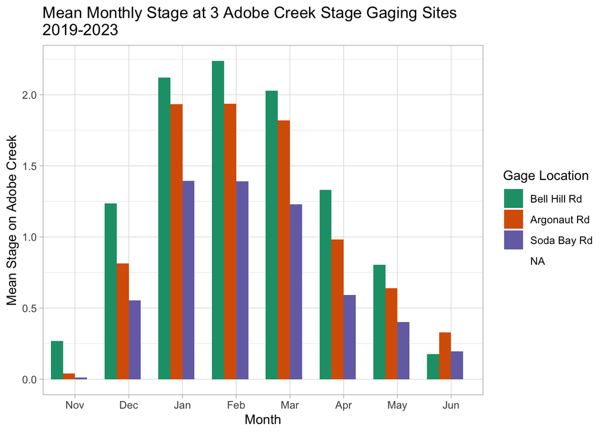

This graphic allows us to interrogate the relationships between stages at the 3 monitoring locations during the most important months for chi spawning.

Kind of interested to look at this relationship for each year…

```r
spawning_months_by_WY <- surface_water  |>
  mutate(
    month = format(datetime, "%m"),
    year = format(datetime, "%Y"),
    WY = ifelse(month %in% c("10","11","12"), as.numeric(year)+1, as.numeric(year))
  )  |>
  filter(month %in% c("12","01","02","03","04","05","06"))  |>
  mutate(month = factor(format(datetime, "%b"), levels = c("Dec", "Jan", "Feb", "Mar", "Apr", "May", "Jun")),
         name = factor(name, levels = c("Bell Hill Rd", "Argonaut Rd", "Soda Bay Rd")))  |>
  group_by(WY, name, month)  |>
  summarize(
    mean = mean(depth_adjust04, na.rm = T)
  )  |>
  ungroup()  |>
  filter(! is.na(name))
```

```r
monthavg2019 <- ggplot(spawning_months_by_WY  |>filter(WY == 2019), aes(x=month, y=mean, fill=name)) +
  geom_col(position = "dodge") +
  theme_light() +
  scale_fill_brewer(type = 'qual', palette = 'Dark2') +
  labs(x = "Month", y = "Average Depth (ft)", fill = "Gage Location", title = "2019") +
  ylim(c(0,4.5))+
  theme_minimal() +
  theme(axis.text.x = element_text(size = 10, angle = 0, vjust = 0),
        axis.title.x = element_blank(),
        panel.grid.major = element_line(colour = "grey60", size = 0.25),
        panel.grid.minor = element_line(colour = "grey80", size = 0.2),
        text = element_text(size = 12),
        plot.title = element_text(hjust=0.5),
        axis.title = element_text(size = 13),
        legend.position = "none",
        legend.margin = margin(t = 0, r = 0, b = 0, l = 0, unit = "in"),
        legend.title = element_blank(),
        plot.margin = margin(t = 0.25, r = 0, b = 0.25, l = 0, unit = "in"))

monthavg2020 <- ggplot(spawning_months_by_WY  |>filter(WY == 2020), aes(x=month, y=mean, fill=name)) +
  geom_col(position = "dodge") +
  theme_light() +
  scale_fill_brewer(type = 'qual', palette = 'Dark2') +
  labs(x = "Month", y = "Average Depth (ft)", fill = "Gage Location", title = "2020") +
  ylim(c(0,4.5))+
  theme_minimal() +
  theme(axis.text.x = element_text(size = 10, angle = 0, vjust = 0),
        axis.title.x = element_blank(),
        panel.grid.major = element_line(colour = "grey60", size = 0.25),
        panel.grid.minor = element_line(colour = "grey80", size = 0.2),
        text = element_text(size = 12),
        plot.title = element_text(hjust=0.5),
        axis.title = element_text(size = 13),
        legend.position = "none",
        legend.margin = margin(t = 0, r = 0, b = 0, l = 0, unit = "in"),
        legend.title = element_blank(),
        plot.margin = margin(t = 0.25, r = 0, b = 0.25, l = 0, unit = "in"))

monthavg2021 <- ggplot(spawning_months_by_WY  |>filter(WY == 2021), aes(x=month, y=mean, fill=name)) +
  geom_col(position = "dodge") +
  theme_light() +
  scale_fill_brewer(type = 'qual', palette = 'Dark2') +
  labs(x = "Month", y = "Average Depth (ft)", fill = "Gage Location", title = "2021") +
  ylim(c(0,4.5))+
  theme_minimal() +
  theme(axis.text.x = element_text(size = 10, angle = 0, vjust = 0),
        axis.title.x = element_blank(),
        panel.grid.major = element_line(colour = "grey60", size = 0.25),
        panel.grid.minor = element_line(colour = "grey80", size = 0.2),
        text = element_text(size = 12),
        plot.title = element_text(hjust=0.5),
        axis.title = element_text(size = 13),
        legend.position = "none",
        legend.margin = margin(t = 0, r = 0, b = 0, l = 0, unit = "in"),
        legend.title = element_blank(),
        plot.margin = margin(t = 0.25, r = 0, b = 0.25, l = 0, unit = "in"))

monthavg2022 <- ggplot(spawning_months_by_WY  |>filter(WY == 2022), aes(x=month, y=mean, fill=name)) +
  geom_col(position = "dodge") +
  theme_light() +
  scale_fill_brewer(type = 'qual', palette = 'Dark2') +
  labs(x = "Month", y = "Average Depth (ft)", fill = "Gage Location", title = "2022") +
  ylim(c(0,4.5))+
  theme_minimal() +
  theme(axis.text.x = element_text(size = 10, angle = 0, vjust = 0),
        axis.title.x = element_blank(),
        panel.grid.major = element_line(colour = "grey60", size = 0.25),
        panel.grid.minor = element_line(colour = "grey80", size = 0.2),
        text = element_text(size = 12),
        plot.title = element_text(hjust=0.5),
        axis.title = element_text(size = 13),
        legend.position = "none",
        legend.margin = margin(t = 0, r = 0, b = 0, l = 0, unit = "in"),
        legend.title = element_blank(),
        plot.margin = margin(t = 0.25, r = 0, b = 0.25, l = 0, unit = "in"))

monthavg2023 <- ggplot(spawning_months_by_WY  |>filter(WY == 2023), aes(x=month, y=mean, fill=name)) +
  geom_col(position = "dodge") +
  scale_fill_brewer(type = 'qual', palette = 'Dark2') +
  labs(x = "Month", y = "Average Depth (ft)", fill = "Gage Location", title = "2023") +
  ylim(c(0,4.5))+
  theme_minimal() +
  theme(axis.text.x = element_text(size = 10, angle = 0, vjust = 0),
        axis.title.x = element_blank(),
        panel.grid.major = element_line(colour = "grey60", size = 0.25),
        panel.grid.minor = element_line(colour = "grey80", size = 0.2),
        text = element_text(size = 12),
        plot.title = element_text(hjust=0.5),
        axis.title = element_text(size = 13),
        legend.position = "none",
        legend.margin = margin(t = 0, r = 0, b = 0, l = 0, unit = "in"),
        legend.title = element_blank(),
        plot.margin = margin(t = 0.25, r = 0, b = 0.25, l = 0, unit = "in"))

# ggsave(
#   "Figs/report/StageMonthlyAvg_2019.png",
#   monthavg2019,
#   device = "png",
#   width = 3.75,
#   height = 2.75,
#   units = "in"
# )
#
# ggsave(
#   "Figs/report/StageMonthlyAvg_2020.png",
#   monthavg2020,
#   device = "png",
#   width = 3.75,
#   height = 2.75,
#   units = "in"
# )
#
# ggsave(
#   "Figs/report/StageMonthlyAvg_2021.png",
#   monthavg2021,
#   device = "png",
#   width = 3.75,
#   height = 2.75,
#   units = "in"
# )
#
# ggsave(
#   "Figs/report/StageMonthlyAvg_2022.png",
#   monthavg2022,
#   device = "png",
#   width = 3.75,
#   height = 2.75,
#   units = "in"
# )
#
# ggsave(
#   "Figs/report/StageMonthlyAvg_2023.png",
#   monthavg2023,
#   device = "png",
#   width = 3.75,
#   height = 2.75,
#   units = "in"
# )
```

### 2.1.7 Flow-Stage Plot Generation

A bit of a stand-in for a rating curve. Just plotting our flow measurements with stages reported from the transducer in these locations.

```r
stage_vs_flow <- stage_flow |> select(c("Site_Name", "Date", "Time", "Flow_cfs", "Corrected_Depth_ft", "WSE_ft-NAVD88")) |>
  mutate(Date = as.Date(Date, format = "%m.%d.%Y"))
```

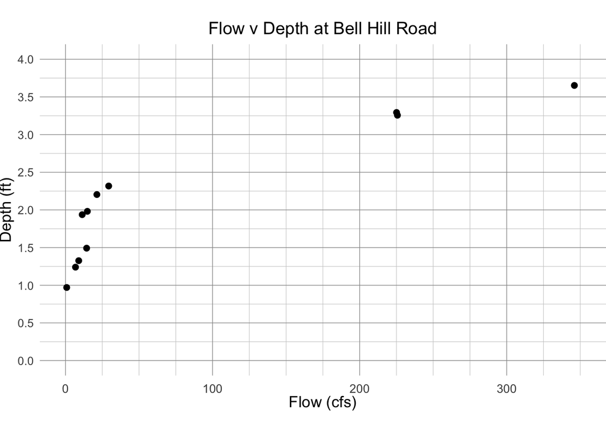

```r
p_bellhill <- ggplot(stage_vs_flow |> filter(Site_Name == "Bell Hill Rd"), aes(y=Corrected_Depth_ft, x=Flow_cfs)) +
  geom_point(size=2) +
  labs(x = "Flow (cfs)", y="Depth (ft)", title="Flow v Depth at Bell Hill Road") +
  scale_y_continuous(limits = c(0,4),
                     breaks = seq(0,4,0.5),
                     minor_breaks = seq(-0.25,4,0.25)) +
  scale_x_continuous(limits = c(0, 350),
                     breaks = seq(0,350,100),
                     minor_breaks = seq(0,350,25)) +
  theme_minimal() +
  theme(axis.text.x = element_text(size = 10, angle = 0, vjust = 0),
        panel.grid.major = element_line(colour = "grey60", size = 0.25),
        panel.grid.minor = element_line(colour = "grey80", size = 0.2),
        text = element_text(size = 12),
        plot.title = element_text(hjust=0.5),
        axis.title = element_text(size = 13),
        legend.margin = margin(t = 0, r = 0, b = 0, l = 0, unit = "in"),
        legend.title = element_blank(),
        plot.margin = margin(t = 0.25, r = 0, b = 0.25, l = 0, unit = "in"))

p_arg <- ggplot(stage_vs_flow |> filter(Site_Name == "Argonaut Rd"), aes(y=Corrected_Depth_ft, x=Flow_cfs)) +
  geom_point(size=2) +
  labs(x = "Flow (cfs)", y="Depth (ft)", title="Flow v Depth at Argonaut Road") +
  scale_y_continuous(limits = c(0,2.5),
                     breaks = seq(0,2.5,0.5),
                     minor_breaks = seq(0,2.5,0.25)) +
  scale_x_continuous(limits = c(0, 100),
                     breaks = seq(0,100,50),
                     minor_breaks = seq(0,100,10)) +
  theme_minimal() +
  theme(axis.text.x = element_text(size = 10, angle = 0, vjust = 0),
        panel.grid.major = element_line(colour = "grey60", size = 0.25),
        panel.grid.minor = element_line(colour = "grey80", size = 0.2),
        text = element_text(size = 12),
        plot.title = element_text(hjust=0.5),
        axis.title = element_text(size = 13),
        legend.margin = margin(t = 0, r = 0, b = 0, l = 0, unit = "in"),
        legend.title = element_blank(),
        plot.margin = margin(t = 0.25, r = 0, b = 0.25, l = 0, unit = "in"))

p_sodabay <- ggplot(stage_vs_flow  |>filter(Site_Name == "Soda Bay Rd"), aes(y=Corrected_Depth_ft, x=Flow_cfs)) +
  geom_point(size=2) +
  labs(x = "Flow (cfs)", y="Depth (ft)", title="Flow v Depth at Soda Bay Road") +
  scale_y_continuous(limits = c(0,2),
                     breaks = seq(0,2,0.5),
                     minor_breaks = seq(0,2,0.25)) +
  scale_x_continuous(limits = c(0, 100),
                     breaks = seq(0,100,50),
                     minor_breaks = seq(0,100,10)) +
  theme_minimal() +
  theme(axis.text.x = element_text(size = 10, angle = 0, vjust = 0),
        panel.grid.major = element_line(colour = "grey60", size = 0.25),
        panel.grid.minor = element_line(colour = "grey80", size = 0.2),
        text = element_text(size = 12),
        plot.title = element_text(hjust=0.5),
        axis.title = element_text(size = 13),
        legend.margin = margin(t = 0, r = 0, b = 0, l = 0, unit = "in"),
        legend.title = element_blank(),
        plot.margin = margin(t = 0.25, r = 0, b = 0.25, l = 0, unit = "in"))

p_bellhill
```

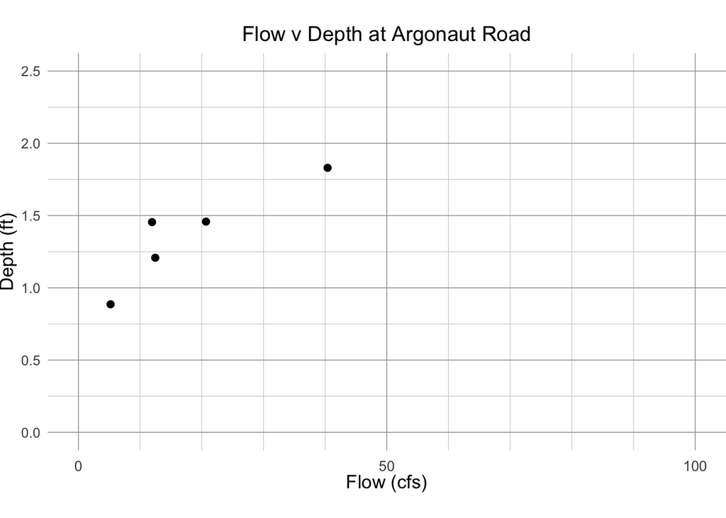

```r
p_arg
```

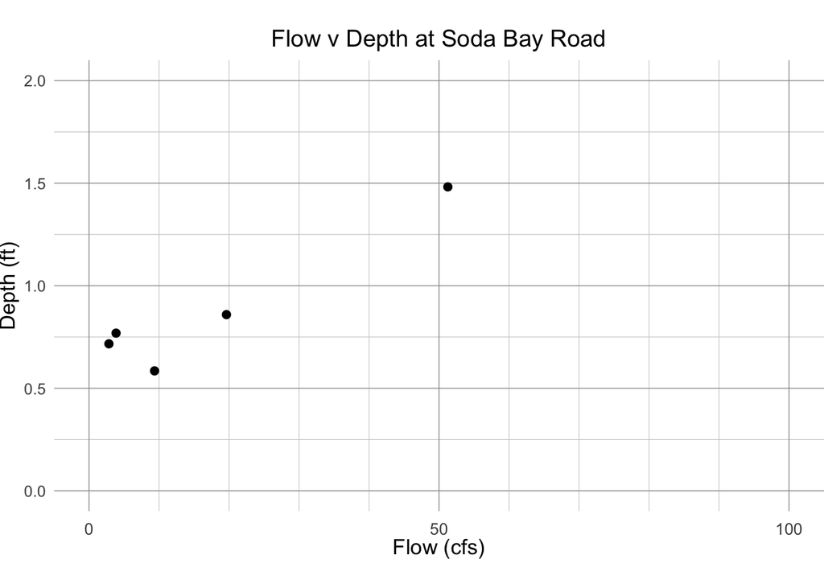

```r
p_sodabay
```

```r
ggsave(
  here::here('data','surface_water', 'figures',  'report', 'FlowVDepth_BellHill.png'),
  p_bellhill,
  device = "png",
  width = 6,
  height = 4,
  units = "in"
)

ggsave(
  here::here('data','surface_water', 'figures',  'report', 'FlowVDepth_Argonaut.png'),
  p_arg,
  device = "png",
  width = 6,
  height = 4,
  units = "in"
)

ggsave(
  here::here('data','surface_water', 'figures',  'report', 'FlowVDepth_SodaBay.png'),
  p_sodabay,
  device = "png",
  width = 6,
  height = 4,
  units = "in"
)
```

### 2.1.8 Data Quality Figures

Highlighting inherent noise and uncertainty

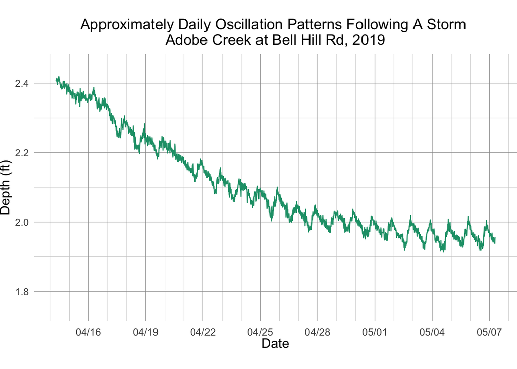

```r
p_base_noise <- ggplot(data = surface_water |> filter(name == "Bell Hill Rd"), aes(x=datetime, y=depth_adjust04, color=name)) +
  geom_line() +
  scale_color_brewer(type = 'qual', palette = 'Dark2') +
  scale_x_datetime(date_labels = "%m/%d",
                   date_breaks = "3 days",
                   minor_breaks = "1 day",
                   limits = c(as.POSIXct("2019-04-14 0:00:00", tz="America/Los_Angeles"), as.POSIXct("2019-05-07 0:00:00", tz="America/Los_Angeles"))) +
  scale_y_continuous(limits = c(1.75,2.45),
                     breaks = c(1.8,2,2.2,2.4)) +
  # theme(axis.text.x = element_text(size = 10, angle = 45),
  #       legend.position = "none") +
  labs(
    title = "Approximately Daily Oscillation Patterns Following A Storm \nAdobe Creek at Bell Hill Rd, 2019",
    y = "Depth (ft)",
    color = "Gage Location",
    x = "Date"
  ) +
  theme_minimal() +
  theme(axis.text.x = element_text(size = 10, angle = 0, vjust = 0),
        panel.grid.major = element_line(colour = "grey60", size = 0.25),
        panel.grid.minor = element_line(colour = "grey80", size = 0.2),
        text = element_text(size = 12),
        plot.title = element_text(hjust=0.5),
        axis.title = element_text(size = 13),
        legend.position = "none",
        legend.direction = "horizontal",
        legend.margin = margin(t = 0, r = 0, b = 0, l = 0, unit = "in"),
        legend.title = element_blank(),
        plot.margin = margin(t = 0.25, r = 0, b = 0.25, l = 0, unit = "in"))

p_base_noise
```

This pattern seems to occur when depth levels off, such as following a storm.

Intensified oscillations in 2023 season on Bell Hill

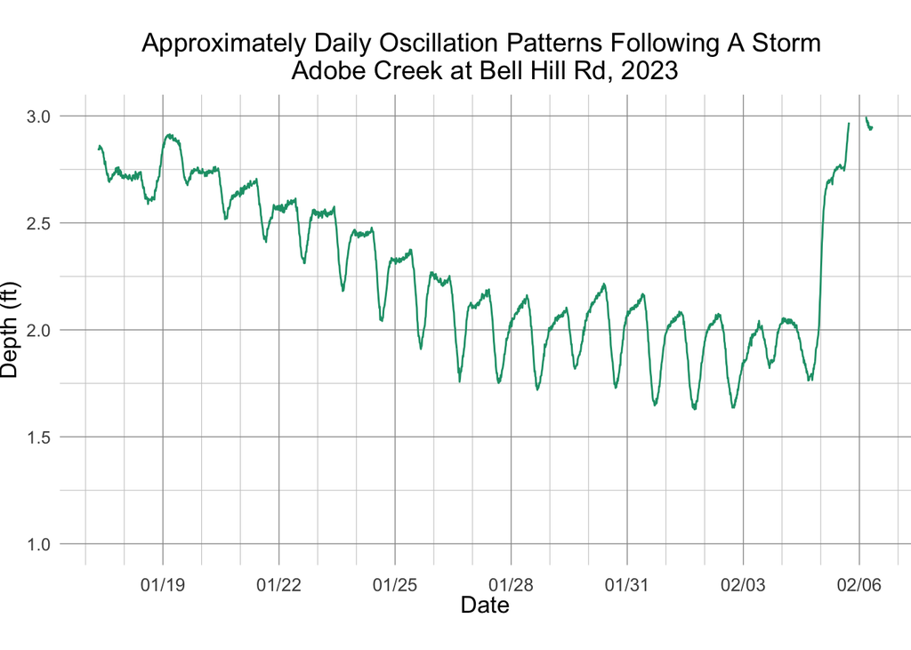

```r
p_worse_noise <- ggplot(data = surface_water  |>filter(name == "Bell Hill Rd"), aes(x=datetime, y=depth_adjust04, color=name)) +
  geom_line() +
  scale_color_brewer(type = 'qual', palette = 'Dark2') +
  scale_x_datetime(date_labels = "%m/%d",
                   date_breaks = "3 days",
                   minor_breaks = "1 day",
                   limits = c(as.POSIXct("2023-01-17 0:00:00", tz="America/Los_Angeles"), as.POSIXct("2023-02-06 0:00:00", tz="America/Los_Angeles"))) +
  scale_y_continuous(limits = c(1,3),
                     breaks = c(1,1.5,2,2.5,3)) +
  labs(
    title = "Approximately Daily Oscillation Patterns Following A Storm \nAdobe Creek at Bell Hill Rd, 2023",
    y = "Depth (ft)",
    color = "Gage Location",
    x = "Date"
  ) +
  theme_minimal() +
  theme(axis.text.x = element_text(size = 10, angle = 0, vjust = 0),
        panel.grid.major = element_line(colour = "grey60", size = 0.25),
        panel.grid.minor = element_line(colour = "grey80", size = 0.2),
        text = element_text(size = 12),
        plot.title = element_text(hjust=0.5),
        axis.title = element_text(size = 13),
        legend.position = "none",
        legend.direction = "horizontal",
        legend.margin = margin(t = 0, r = 0, b = 0, l = 0, unit = "in"),
        legend.title = element_blank(),
        plot.margin = margin(t = 0.25, r = 0, b = 0.25, l = 0, unit = "in"))

p_worse_noise
```

We can see that this oscillation is much worse in 2023. Some oscillations are almost 0.5 feet! This is not a real physical phenomenon.

Zero water depth osciallations

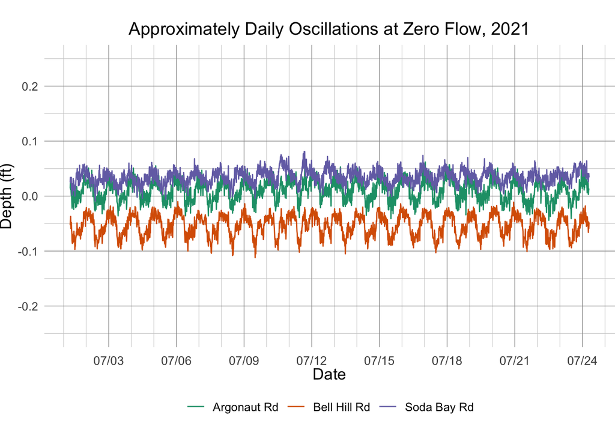

```r
p_zeroflow_noise <- ggplot(data = surface_water  |>filter(name %in% c("Bell Hill Rd", "Argonaut Rd", "Soda Bay Rd")), aes(x=datetime, y=depth_adjust02, color=name)) +
  geom_line() +
  scale_color_brewer(type = 'qual', palette = 'Dark2') +
  scale_x_datetime(date_labels = "%m/%d",
                   date_breaks = "3 days",
                   minor_breaks = "1 day",
                   limits = c(as.POSIXct("2021-07-01 0:00:00", tz="America/Los_Angeles"), as.POSIXct("2021-07-24 0:00:00", tz="America/Los_Angeles"))) +
  scale_y_continuous(limits = c(-0.25,0.25)) +
  labs(
    title = "Approximately Daily Oscillations at Zero Flow, 2021",
    y = "Depth (ft)",
    color = "Gage Location",
    x = "Date"
  ) +
  theme_minimal() +
  theme(axis.text.x = element_text(size = 10, angle = 0, vjust = 0),
        panel.grid.major = element_line(colour = "grey60", size = 0.25),
        panel.grid.minor = element_line(colour = "grey80", size = 0.2),
        text = element_text(size = 12),
        plot.title = element_text(hjust=0.5),
        axis.title = element_text(size = 13),
        legend.position = "bottom",
        legend.direction = "horizontal",
        legend.margin = margin(t = 0, r = 0, b = 0, l = 0, unit = "in"),
        legend.title = element_blank(),
        plot.margin = margin(t = 0.25, r = 0, b = 0.25, l = 0, unit = "in"))

p_zeroflow_noise
```

Argonaut Error in 2023

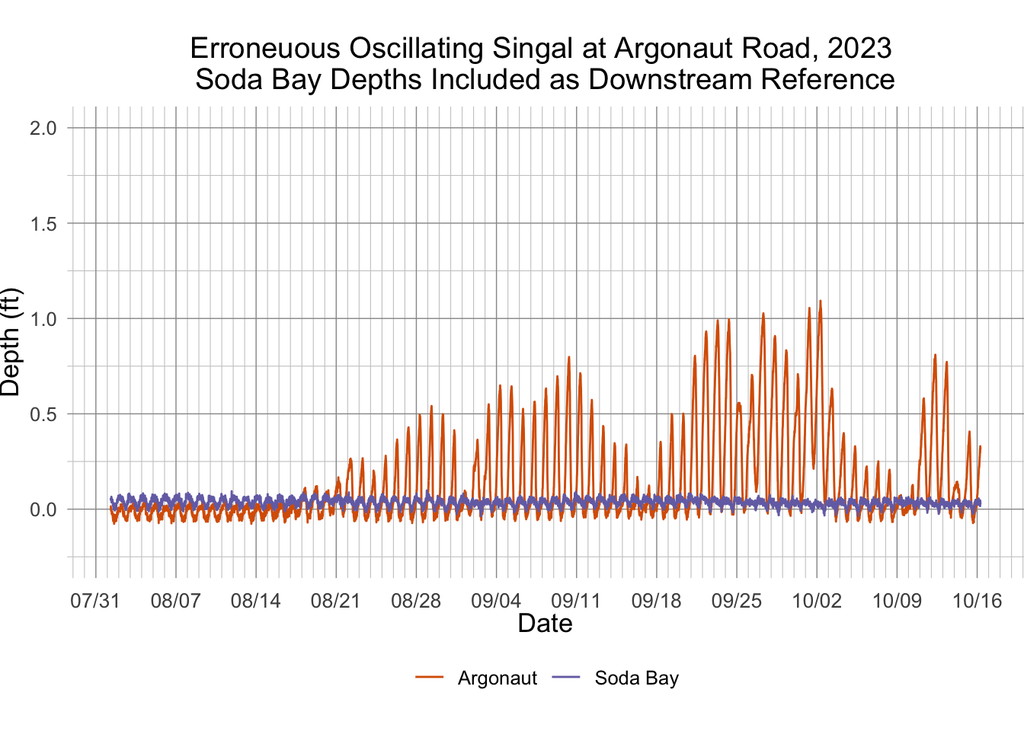

```r
p_argonaut_error <- ggplot(data = surface_water |>filter(name == "Argonaut Rd"), aes(x=datetime, y=depth_adjust02, color="Argonaut")) +
  geom_line() +
  geom_line(data = surface_water |>filter(name == "Soda Bay Rd"), aes(color="Soda Bay")) +
  scale_color_manual(name = "", values = c("Argonaut" = "#D95F02", "Soda Bay" = "#7570B3")) +
  scale_x_datetime(date_labels = "%m/%d",
                   date_breaks = "1 week",
                   minor_breaks = "1 day",
                   limits = c(as.POSIXct("2023-08-01 0:00:00", tz="America/Los_Angeles"), as.POSIXct("2023-10-16 0:00:00", tz="America/Los_Angeles"))) +
  scale_y_continuous(limits = c(-0.25,2),
                     breaks = c(0, 0.5, 1, 1.5, 2)) +
  labs(
    title = "Erroneuous Oscillating Singal at Argonaut Road, 2023 \nSoda Bay Depths Included as Downstream Reference",
    y = "Depth (ft)",
    color = "Gage Location",
    x = "Date"
  ) +
  theme_minimal() +
  theme(axis.text.x = element_text(size = 10, angle = 0, vjust = 0),
        panel.grid.major = element_line(colour = "grey60", size = 0.25),
        panel.grid.minor = element_line(colour = "grey80", size = 0.2),
        text = element_text(size = 12),
        plot.title = element_text(hjust=0.5),
        axis.title = element_text(size = 13),
        legend.position = "bottom",
        legend.direction = "horizontal",
        legend.margin = margin(t = 0, r = 0, b = 0, l = 0, unit = "in"),
        legend.title = element_blank(),
        plot.margin = margin(t = 0.25, r = 0, b = 0.25, l = 0, unit = "in"))

p_argonaut_error
```

Bell Hill Sudden Datum Shift

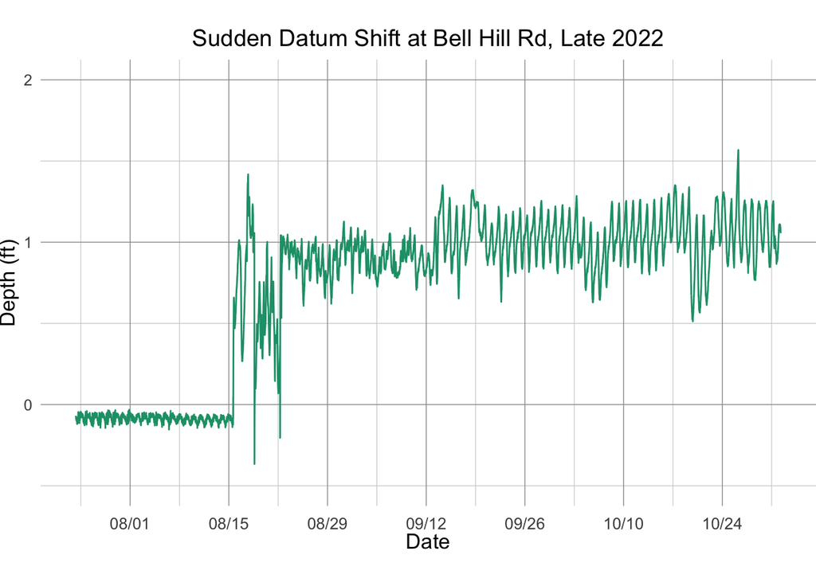

```r
p_bellhill_datumshift <- ggplot(data = surface_water  |>filter(name == "Bell Hill Rd"), aes(x=datetime, y=depth_ft, color=name)) +
  geom_line() +
  scale_color_brewer(type = 'qual', palette = 'Dark2') +
  scale_x_datetime(date_labels = "%m/%d",
                   date_breaks = "2 weeks",
                   minor_breaks = "1 week",
                   limits = c(as.POSIXct("2022-07-24 0:00:00", tz="America/Los_Angeles"), as.POSIXct("2022-11-01 0:00:00", tz="America/Los_Angeles"))) +
  scale_y_continuous(limits = c(-0.5,2),
                     breaks = c(0,1,2)) +
  labs(
    title = "Sudden Datum Shift at Bell Hill Rd, Late 2022",
    y = "Depth (ft)",
    color = "Gage Location",
    x = "Date"
  ) +
  theme_minimal() +
  theme(axis.text.x = element_text(size = 10, angle = 0, vjust = 0),
        panel.grid.major = element_line(colour = "grey60", size = 0.25),
        panel.grid.minor = element_line(colour = "grey80", size = 0.2),
        text = element_text(size = 12),
        plot.title = element_text(hjust=0.5),
        axis.title = element_text(size = 13),
        legend.position = "none",
        legend.direction = "horizontal",
        legend.margin = margin(t = 0, r = 0, b = 0, l = 0, unit = "in"),
        legend.title = element_blank(),
        plot.margin = margin(t = 0.25, r = 0, b = 0.25, l = 0, unit = "in"))

p_bellhill_datumshift
```

Save out all of these figures

```r
ggsave(
  here::here('data','surface_water', 'figures',  'report', 'data_quality', 'AdobeOscillation_Normal.png'),
  p_base_noise,
  device = "png",
  width = 6,
  height = 4,
  units = "in"
)

ggsave(
  here::here('data','surface_water', 'figures',  'report', 'data_quality', 'AdobeOscillation_2023.png'),
  p_worse_noise,
  device = "png",
  width = 6,
  height = 4,
  units = "in"
)

ggsave(
  here::here('data','surface_water', 'figures',  'report', 'data_quality', 'NoFlow_Noise.png'),
  p_zeroflow_noise,
  device = "png",
  width = 6,
  height = 4,
  units = "in"
)

ggsave(
  here::here('data','surface_water', 'figures',  'report', 'data_quality', 'Argonaut_BadData.png'),
  p_argonaut_error,
  device = "png",
  width = 6,
  height = 4,
  units = "in"
)

ggsave(
  here::here('data','surface_water', 'figures',  'report', 'data_quality', 'BellHill_DatumShift.png'),
  p_bellhill_datumshift,
  device = "png",
  width = 6,
  height = 4,
  units = "in"
)
```

### 2.1.9 Reservoir Figures

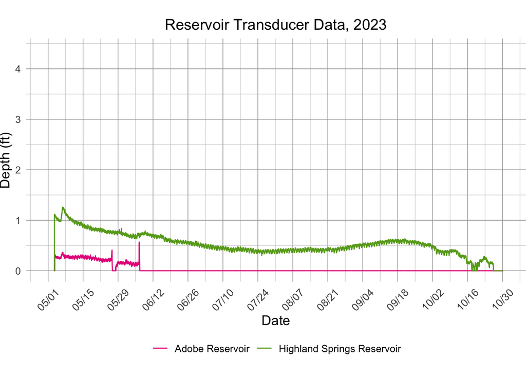

```r
p_reservoir_data <- ggplot(data = surface_water  |>filter(name == "Adobe Reservoir"), aes(x=datetime, y=depth_adjust04, color= "Adobe Reservoir")) +
  geom_line() +
  geom_line(data = surface_water  |>filter(name == "Highland Springs Reservoir"), aes(x=datetime, y=depth_adjust04, color= "Highland Springs Reservoir")) +
  scale_color_manual(name = "", values = c("Adobe Reservoir" = "#e7298a", "Highland Springs Reservoir" = "#66a61e")) +
  scale_x_datetime(date_labels = "%m/%d",
                   date_breaks = "2 weeks",
                   minor_breaks = "1 week",
                   limits = c(as.POSIXct("2023-05-01 0:00:00", tz="America/Los_Angeles"), as.POSIXct("2023-10-30 0:00:00", tz="America/Los_Angeles"))) +
  # scale_y_continuous(limits = c(-0.5,2),
  #                    breaks = c(0,1,2)) +
  labs(
    title = "Reservoir Transducer Data, 2023",
    y = "Depth (ft)",
    color = "Gage Location",
    x = "Date"
  ) +
  theme_minimal() +
  theme(axis.text.x = element_text(size = 10, angle = 45, vjust = 0.5),
        panel.grid.major = element_line(colour = "grey60", size = 0.25),
        panel.grid.minor = element_line(colour = "grey80", size = 0.2),
        text = element_text(size = 12),
        plot.title = element_text(hjust=0.5),
        axis.title = element_text(size = 13),
        legend.position = "bottom",
        legend.direction = "horizontal",
        legend.margin = margin(t = 0, r = 0, b = 0, l = 0, unit = "in"),
        legend.title = element_blank(),
        plot.margin = margin(t = 0.25, r = 0, b = 0.25, l = 0, unit = "in"))

p_reservoir_data
```

```r
ggsave(
 here::here('data','surface_water', 'figures',  'report', 'data_quality', 'reserviors_cleaned.png'),
  p_reservoir_data,
  device = "png",
  width = 6,
  height = 4,
  units = "in"
)
```

```r
knitr::knit_exit()
```